# An Knitr Example Using Warpbreaks Data

Justin Meyer

February 17, 2015

To make a knitr file go to File then New File then R Markdown…

RStudio will ask you to install some necessary packages.

RStudio can turn this code into an HTML file, a PDF, or a Word doc. A PDF requires that you have TeX installed. MikTex is recommended for Windows. A Word doc requires that you have Word installed.

The above text will show up in the output document just as it appears here.

You can use Markdown to add formatting to the text. There is example markdown at [This link](http://daringfireball.net/projects/markdown/syntax).

Here are some bullets: - Note 1 - Note 2

We can also add a pagebreak. Note that pagebreak is done with LaTeX. Some LaTeX works and some doesn’t.

# This Page has an H1 Header

The following is some R code that will run. echo = FALSE hides the R code so only the output is shown

### Here is the Table

| Wool | Tension | Average Breaks | Number of Samples |
| --- | --- | --- | --- |
| A | L | 44.55556 | 9 |
| A | M | 24.00000 | 9 |
| A | H | 24.55556 | 9 |
| B | L | 28.22222 | 9 |
| B | M | 28.77778 | 9 |
| B | H | 18.77778 | 9 |

# A Chart Summarizing the Warpbreaks Data

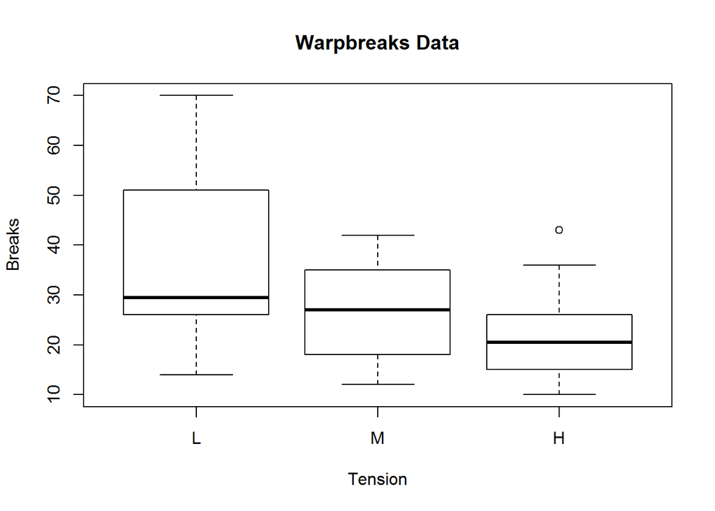

Add inline R code like this:

There are 157,464 rows cubed in the warpbreaks dataset.

prettyNum isn’t necessary but it adds commas that improve readability.